# 8va Semana (11/02/2021) - Derivadas, máximos y mínimos con Python

Supongamos que en $x=x_1$ la derivada de la función $y=f(x)$ se reduce a cero, es decir, $f'(x)=0$. Admitamos, además que existe la segunda derivada, $f''(x)$, y es continua sobre cierta vecindad del punto $x_1$. Para este caso es válido el siguiente teorema:

> **Teorema 1.** Si $f'(x_1)=0$, entonces en $x=x_1$ la función tiene máximo cuando $f''(x_1)<0$, y, un mínimo cuando $f''(x_1)>0$.

De acuerdo al teorema anterior, para caracterizar los puntos críticos de una función $f(x)$ es necesario utilizar el criterio de la segunda derivada. Entendiendo que los puntos críticos se obtiene de resolver la ecuación $f'(x)=0$.

En Python es posible realizar cálculo simbólico mediante la librería SymPy.

**Ejemplo 1.** *Calcular y caracterizar los puntos críticos de la función $f(x) = x^3 - x$*

Primero, y como siempre, importamos los módulos necesarios.

## Cálculo de máximos y mínimos

Para encontrar los extremos relativos o locales de una función f(x), realizaremos lo siguiente:

1) Hallar la primera derivada f'(x) y obtener sus raíces.

2) Hallar la segunda derivada f''(x), y calcular los valores que toman los ceros de la primer derivada en f''(x), luego, determinar si es un máximo o mínimo de acuerdo a la condición, recordando que si:

f''(x) > 0 Tenemos un mínimo

f''(x) < 0 Tenemos un máximo

3) Calcular la segunda coordenada de los extremos relativos en la función f(x).

### Pregunta: ¿Que pasa si f''(x) = 0?

```python
!pip install sympy
```

```python
from sympy import *
from sympy.plotting import plot
from sympy.abc import x
init_printing()
```

Definimos la función con la cual operaremos:

```python
f = x**3 - x
```

Acto seguido, calculamos la primera y segunda derivada de $f(x)$ mediante la función `diff`:

```python
df = diff(f, x) # 1era. derivada
d2f = diff(f,x,2) # Segunda derivada
df, d2f
```

$\displaystyle \left( 3 x^{2} - 1, \ 6 x\right)$

Los puntos críticos los calculamos resolviendo la ecuación $f'(x)=0$

```python
pc = solve(Eq(df, 0))
pc
```

$\displaystyle \left[ - \frac{\sqrt{3}}{3}, \ \frac{\sqrt{3}}{3}\right]$

Para determinar si se trata de un mínimo o máximo, utilizamos el criterio de la segunda derivada, sustituyendo los puntos críticos en $f''(x)$, es decir:

```python
d2f.subs(x,pc[0]) # Primer punto crítico
```

$\displaystyle - 2 \sqrt{3}$

```python
d2f.subs(x,pc[1]) # Segundo punto crítico
```

$\displaystyle 2 \sqrt{3}$

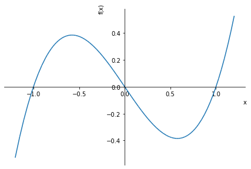

```
<sympy.plotting.plot.Plot at 0x1b235446f48>
```

```python
plot(f, (x, -1.2, 1.2))
```

Podemos *automatizar* un poco este proceso definiendo una función que realice el procedimiento descrito.

```python
def maxminf(f):
    """ Calcula los máximos y mínimos de una función f(x) """
    df = diff(f, x) # 1era. derivada
    d2f = diff(f, x, 2) # 2da. derivada
    pcs = solve(Eq(df,0)) # puntos críticos
    for p in pcs:
        if d2f.subs(x,p)>0:
            tipo="Min"
        elif d2f.subs(x,p)<0:
            tipo="Max"
        else:
            tipo="Indefinido"
        print("x = %f (%s)"%(p,tipo))
```

```python
maxminf(x**3 - x)
```

```
x = -0.577350 (Max)
x = 0.577350 (Min)
```

La función anterior puede arrojar errores cuando se tienen raíces complejas, lo cual podría considerarse mediante una estructura try-except o bien verificando si el punto crítico es un valor real.